# PancreasDE

Mike Morgan

27 October 2017

## Differential expression analysis - pancreas islet cells

First things first is to load all of the necessary packages. To properly recapitulate the manuscript figure for the DE analysis, I’ll add the ggplot themes and functions. I’ll also define a couple of convenience functions for later.

```r
# load required packages for generating manuscript figures
library(ggplot2)
library(limma)
library(RColorBrewer)
library(goseq)
library(org.Hs.eg.db)
library(flashClust)
library(VennDiagram)
library(biomaRt)
library(stringr)
library(WGCNA)
library(ggrepel)
library(cowplot)

# setup ggplot theme
theme_mike <- function(base_size=14) {
  library(grid)
  library(ggthemes)
  (theme_foundation(base_size=base_size)
  + theme(plot.title = element_text(face = "bold",
                                    size = rel(1.2), hjust = 0.5),
          text = element_text(size=16),
          panel.background = element_rect(colour = NA),
          plot.background = element_rect(colour = NA),
          panel.border = element_rect(colour = NA),
          axis.title = element_text(face = "bold",size = rel(1)),
          axis.title.y = element_text(angle=90,vjust =2),
          axis.title.x = element_text(vjust = -0.2),
          axis.text = element_text(),
          axis.line = element_line(colour="black"),
          axis.ticks = element_line(),
          panel.grid.major = element_line(colour="#f0f0f0"),
          panel.grid.minor = element_blank(),
          legend.key = element_rect(colour = NA),
          legend.position = "bottom",
          legend.direction = "horizontal",
          legend.key.width= unit(1.0, "cm"),
          legend.key.height = unit(0.5, "cm"),
          legend.title = element_text(face="italic"),
          plot.margin=unit(c(10,5,5,5),"mm"),
          strip.background=element_rect(colour="#f0f0f0",fill="#f0f0f0"),
          strip.text = element_text(face="bold")
  ))
}

scale_fill_Publication <- function(...){
  library(scales)
  discrete_scale("fill","Publication",
                 manual_pal(values = c("#386cb0", "#fdb462",
                                       "#7fc97f","#ef3b2c","#662506",
                                       "#a6cee3","#fb9a99","#984ea3",
                                       "#ffff33", "#b2df8a", "#3E89BE",
                                       "#CA834E", "#518A87", "#5B113C",
                                       "#55813B", "#E704C4", "#DDAEA2",
                                       "#77837F", "#A53327", "#608EFF",
                                       "#B599D7", "#A50149", "#4E0025",
                                       "#C9B1A9",
                                       "#33a02c", "#fb9a99", "#e31a1c",
                                       "#fdbf6f", "#ff7f00", "#cab2d6",
                                       "#6a3d9a", "#ffff99", "#b15928")), ...)

}

scale_colour_Publication <- function(...){
  library(scales)
  discrete_scale("colour", "Publication",
                 manual_pal(values = c("#386cb0", "#fdb462",
                                       "#7fc97f","#ef3b2c","#662506",
                                       "#a6cee3","#fb9a99","#984ea3",
                                       "#ffff33", "#b2df8a", "#3E89BE",
                                       "#CA834E", "#518A87", "#5B113C",
                                       "#55813B", "#E704C4", "#DDAEA2",
                                       "#77837F", "#A53327", "#608EFF",
                                       "#B599D7", "#A50149", "#4E0025",
                                       "#C9B1A9",
                                       "#33a02c", "#fb9a99", "#e31a1c",
                                       "#fdbf6f", "#ff7f00", "#cab2d6",
                                       "#6a3d9a", "#ffff99", "#b15928")), ...)

}

tsne_wrapper <- function(dataframe, perplexity=30, is.dist=FALSE){
  require(Rtsne)
  set.seed(42)
  if(is.dist){
    data.tsne <- Rtsne(t(dataframe),
                       perplexity=perplexity, is_distance=is.dist, pca=FALSE)
    sample.names <- labels(dataframe)

  }
  else {
    dataframe <- dataframe[, !duplicated(t(dataframe))]
    data.tsne <- Rtsne(t(dataframe), perplexity=perplexity)
    sample.names <- colnames(dataframe)
  }
  data.map <- data.frame(data.tsne$Y)
  colnames(data.map) <- c("Dim1", "Dim2")
  data.map$Sample <- sample.names

  return(data.map)
}
```

The raw data should have been downloaded with `DownloadData.sh`, and the batch corrected data should have been generated by running `source("Pancreas/preparedata.R")` followed by `source("Pancreas/FourPlots_panc.R")` in an R session. If you are running this notebook in an active RStudio session you can just source these two R scripts before executing the rest of this notebook.

First we’ll load all of the raw and batch corrected data into the R environment. This might take a little while as these are quite large data sets (1000s of cells each).

```r
# all paths assume code is executed in the MNN2017 repository directory
# change these as necessary
# all corrected data are in a single file
all.correct <- read.table("../Pancreas/Data/mnnCorrected.tsv",
                          h=TRUE, sep="\t", stringsAsFactors=FALSE)
rownames(all.correct) <- all.correct$gene_id

gse81076.raw <- read.table("../Pancreas/Data/GSE81076_SFnorm.tsv", sep="\t",
                           h=T, stringsAsFactors=F)

gse85241.raw <- read.table("../Pancreas/Data/GSE85241_SFnorm.tsv", sep="\t",
                           h=T, stringsAsFactors=F)

emtab5061.raw <- read.table("../Pancreas/Data/E-MTAB-5061_SFnorm.tsv", sep="\t",
                           h=T, stringsAsFactors=F)

gse86473.raw <- read.table("../Pancreas/Data/GSE86473_SFnorm.tsv", sep="\t",
                               h=T, stringsAsFactors=F)

all.genes <- unique(all.correct$gene_id)

ensembl <- useEnsembl(biomart='ENSEMBL_MART_ENSEMBL', dataset='hsapiens_gene_ensembl', GRCh=37)

gene_symbol <- getBM(attributes=c('ensembl_gene_id', 'external_gene_name'),
                     filters='external_gene_name', mart=ensembl,
                     values=all.genes)
```

We also need to retrieve the meta data and highly variable genes, which are downloaded from the FTP server along with the highly variable gene sets and the raw data.

```r
# meta data
gse81076.meta <- read.table("../Pancreas/Data/GSE81076_marker_metadata.tsv", sep="\t",
                            stringsAsFactors=F, h=TRUE)

gse85241.meta <- read.table("../Pancreas/Data/GSE85241_marker_metadata.tsv", sep="\t",
                            stringsAsFactors=F, h=T)

emtab5061.meta <- read.table("../Pancreas/Data/E-MTAB-5061_metadata.tsv", sep="\t",
                            stringsAsFactors=F, h=T)
emtab5061.meta$Study <- "EMTAB5061"

gse86473.meta <- read.table("../Pancreas/Data/GSE86473_metadata.tsv", sep="\t",
                            stringsAsFactors=F, h=T)

gse86473.hvg <- read.table("../Pancreas/Data/GSE86473-HVG.tsv", h=F, sep="\t",
                           stringsAsFactors=F)

gse81076.hvg <- read.table("../Pancreas/Data/GSE81076-HVG.tsv", h=F, sep="\t",
                           stringsAsFactors=F)

emtab5061.hvg <- read.table("../Pancreas/Data/E-MTAB-5061-HVG.tsv", h=F, sep="\t",
                           stringsAsFactors=F)

gse85241.hvg <- read.table("../Pancreas/Data/GSE85241-HVG.tsv", h=F, sep="\t",
                           stringsAsFactors=F)
```

The comparison of the two smallest cell populations would be in gse81076, between the delta islets and the PP cells. We want to naively cluster the cells together and find the cells that relate to say, PP and delta cells based on marker genes, etc. This would essentially reflect the sort of work-flow that would be performed when the cell type labels are not known *a priori*. Then using the same cells on the uncorrected data, we want to show that we can find more DE genes after correction, clustering, etc.

```r
merged.meta <- data.frame(do.call(rbind, list("GSE81076"=gse81076.meta[, c("Sample", "Study", "CellType")],
                                              "GSE85241"=gse85241.meta[, c("Sample", "Study", "CellType")],
                                              "EMTAB5061"=emtab5061.meta[, c("Sample", "Study", "CellType")],
                                              "GSE86473"=gse86473.meta[, c("Sample", "Study", "CellType")])))
merged.meta$CellType <- gsub(tolower(merged.meta$CellType), pattern=" cell", replacement="")

table(merged.meta$CellType)
```

```
##
##                                        acinar                  alpha
##                      3                    711                   2862
##                   beta          co-expression                  delta
##                   1407                     39                    424
##                 ductal            endothelial                epsilon
##                    979                     16                      7
##                  gamma                   mast             mesenchyme
##                    197                      7                    159
##           mhc class ii         not applicable                     pp
##                      5                    128                    236
##                    psc           unclassified unclassified endocrine
##                     54                      2                     41
```

## Cell clustering

We now want to cluster cells and try to find their cell label(s), before doing a DE analysis on those cells (using the original uncorrected expression values).

### Clustering using MNN corrected data

```r
# remove the small scrappy cell types, there are at least 30 cells
inc.types <- c("pp", "alpha", "beta", "acinar", "delta", "ductal", "mesenchyme", "psc", "gamma")
inc.cells <- merged.meta$Sample[merged.meta$CellType %in% inc.types]

# cluster cells on the hvg
all.cells <- all.correct[, intersect(inc.cells, colnames(all.correct))]
all.cells[is.na(all.cells)] <- 0
all.cells <- all.cells[, intersect(colnames(all.cells), merged.meta$Sample)]
merged.meta <- merged.meta[merged.meta$Sample %in% intersect(colnames(all.cells), merged.meta$Sample), ]
rownames(merged.meta) <- merged.meta$Sample

# get the cell IDs for each study
gse81076.cells <- merged.meta$Sample[merged.meta$Study == "GSE81076"]
gse86473.cells <- merged.meta$Sample[merged.meta$Study == "GSE86473"]
emtab5061.cells <- merged.meta$Sample[merged.meta$Study == "EMTAB5061"]
gse85241.cells <- merged.meta$Sample[merged.meta$Study == "GSE85241"]
```

```r
# NB: this is a slow operation as there are ~7000 cells to embed
set.seed(42)
all.tsne <- tsne_wrapper(all.cells, perplexity=50)
all.tsne$Sample <- colnames(all.cells)
all.merge <- merge(all.tsne, merged.meta, by='Sample')
```

```r
# try a k-means with k=8 as we expect ~8 different cell types across all 4 data sets
set.seed(42)
all.kmeans <- kmeans(all.tsne[, 1:2], centers=8)
kmean.df <- data.frame(cbind(colnames(all.cells), all.kmeans$cluster))
colnames(kmean.df) <- c("Sample", "Kmeans")

kmean.merge <- merge(all.merge, kmean.df, by='Sample')
```

Let’s plot the tSNE, colour by the kmeans partition. Please note that since the original manuscript submission minor alterations in the MNNCorrect code have resulted in qualitatively different plots. The same partitioning is possible, but due to the stochastic nature of tSNE, small changes in values can propagate into apparently large differences in tSNE visualisation.

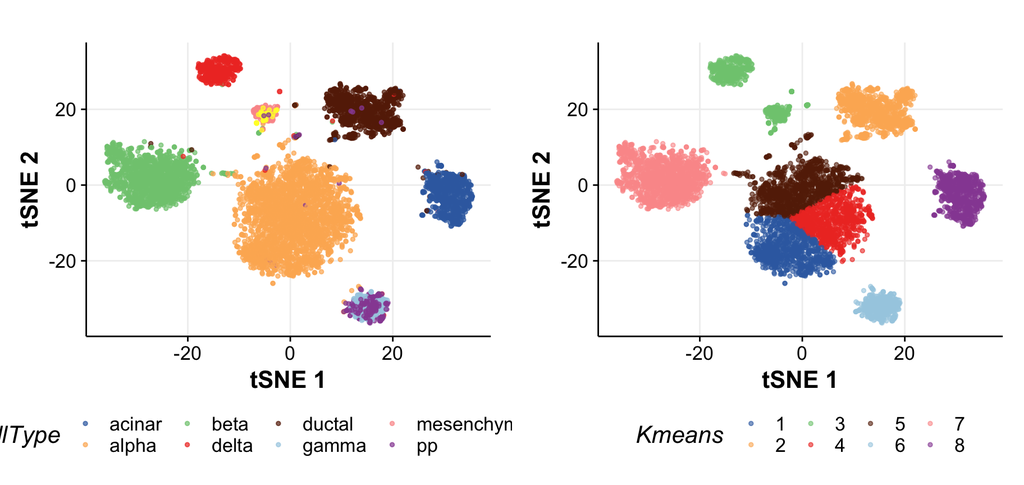

```r
by.cell <- ggplot(kmean.merge, aes(x=Dim1, Dim2, colour=CellType)) +
  geom_point(size=1, alpha=0.7) + theme_mike() +
  scale_colour_Publication() +
  labs(x="tSNE 1", y="tSNE 2")

by.study <- ggplot(kmean.merge, aes(x=Dim1, Dim2, colour=Kmeans)) +
  geom_point(size=1, alpha=0.6) + theme_mike() +
  scale_colour_Publication() +
  labs(x="tSNE 1", y="tSNE 2")

plot_grid(by.cell, by.study)
```

K-means on the tSNE dimensions does pretty well, it splits some of the larger clusters though, but it is obvious these should be merged into a single cluster. Let’s overlay the different marker genes from the original publications onto these cells to identify what types they are.

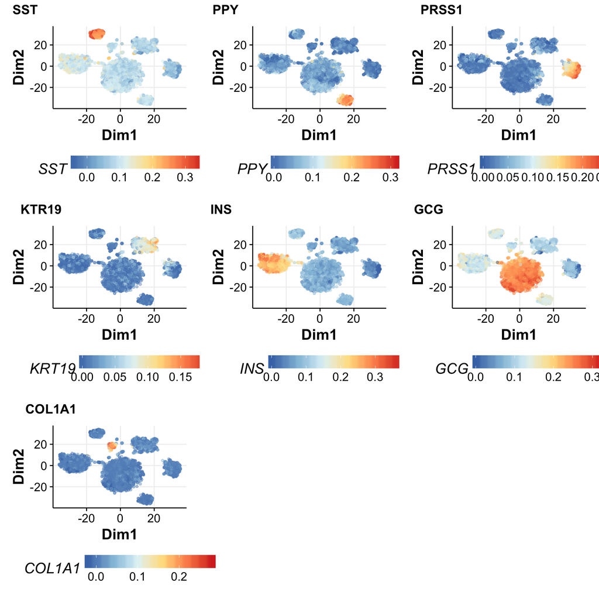

```r
marker.genes <- c("SST", "PPY", "PRSS1", "KRT19", "INS", "GHRL", "GCG", "ESAM", "COL1A1")
marker.exprs <- data.frame(t(all.cells[marker.genes, ]))
marker.exprs$Sample <- rownames(marker.exprs)

meta.marker <- merge(kmean.merge, marker.exprs, by='Sample')

sst.p <- ggplot(meta.marker, aes(x=Dim1, Dim2, colour=SST)) +
  geom_point(size=1, alpha=0.4) + theme_mike() +
  scale_colour_distiller(palette="RdYlBu", direction=-1) +
  guides(shape=FALSE)

ppy.p <- ggplot(meta.marker, aes(x=Dim1, Dim2, colour=PPY)) +
  geom_point(size=1, alpha=0.4) + theme_mike() +
  scale_colour_distiller(palette="RdYlBu", direction=-1) +
  guides(shape=FALSE)

prss1.p <- ggplot(meta.marker, aes(x=Dim1, Dim2, colour=PRSS1)) +
  geom_point(size=1, alpha=0.4) + theme_mike() +
  scale_colour_distiller(palette="RdYlBu", direction=-1) +
  guides(shape=FALSE)

krt19.p <- ggplot(meta.marker, aes(x=Dim1, Dim2, colour=KRT19)) +
  geom_point(size=1, alpha=0.4) + theme_mike() +
  scale_colour_distiller(palette="RdYlBu", direction=-1) +
  guides(shape=FALSE)

ins.p <- ggplot(meta.marker, aes(x=Dim1, Dim2, colour=INS)) +
  geom_point(size=1, alpha=0.4) + theme_mike() +
  scale_colour_distiller(palette="RdYlBu", direction=-1) +
  guides(shape=FALSE)

gcg.p <- ggplot(meta.marker, aes(x=Dim1, Dim2, colour=GCG)) +
  geom_point(size=1, alpha=0.4) + theme_mike() +
  scale_colour_distiller(palette="RdYlBu", direction=-1) +
  guides(shape=FALSE)

esam.p <- ggplot(meta.marker, aes(x=Dim1, Dim2, colour=ESAM)) +
  geom_point(size=1, alpha=0.4) + theme_mike() +
  scale_colour_distiller(palette="RdYlBu", direction=-1) +
  guides(shape=FALSE)

col1a1.p <- ggplot(meta.marker, aes(x=Dim1, Dim2, colour=COL1A1)) +
  geom_point(size=1, alpha=0.4) + theme_mike() +
  scale_colour_distiller(palette="RdYlBu", direction=-1)

plot_grid(sst.p, ppy.p, prss1.p, krt19.p, ins.p, gcg.p, col1a1.p,
          ncol=3, labels=c("SST", "PPY", "PRSS1", "KTR19", "INS", "GCG", "COL1A1"))
```

Let’s define them explicitly:

```r
meta.marker$new.labels <- "Unk"
meta.marker$new.labels[meta.marker$Kmeans == 3 & meta.marker$SST >= 0.1] <- "Delta"
meta.marker$new.labels[meta.marker$Kmeans == 7] <- "Beta"
meta.marker$new.labels[meta.marker$Kmeans == 1] <- "Alpha"
meta.marker$new.labels[meta.marker$Kmeans == 4] <- "Alpha"
meta.marker$new.labels[meta.marker$Kmeans == 5] <- "Alpha"
meta.marker$new.labels[meta.marker$Kmeans == 8] <- "Acinar"
meta.marker$new.labels[meta.marker$Kmeans == 6] <- "Gamma"
meta.marker$new.labels[meta.marker$Kmeans == 2] <- "Ductal"
meta.marker$new.labels[meta.marker$Kmeans == 3 & meta.marker$COL1A1 >= 0.1] <- "Mesenchyme"

table(meta.marker$CellType, meta.marker$new.labels)
```

```
##
##              Acinar Alpha Beta Delta Ductal Gamma Mesenchyme  Unk
##   acinar        703     2    0     0      6     0          0    0
##   alpha           0  2801    1     0     17     9         16    4
##   beta            0    18 1355     3     12     2          9    0
##   delta           1     2    1   407      2     3          4    1
##   ductal         13    11    3     8    934     0          0    6
##   gamma           0     0    0     0      0   194          0    0
##   mesenchyme      1     0    0    10      1     0        120   27
##   pp              0    12    0     0      4   217          2    0
##   psc             0     0    0     0      0     0         53    0
```

```r
print(randIndex(table(meta.marker$CellType, meta.marker$new.labels), adjust=TRUE))
```

```
## [1] 0.9436519
```

The gamma and pp cells are the same, but different studies use different labels. Here, as described in the manuscript, we consider them all to be of the same type, labelled `Gamma`. We also merge together the mesenchyme and PSC cells as we cannot discriminate between them transcriptionally. The adjusted Rand index, assuming the original cell type labels as the ground truth, is 0.9436519.

Below is the equivalent to Supplementary Figure4a in the manuscript.

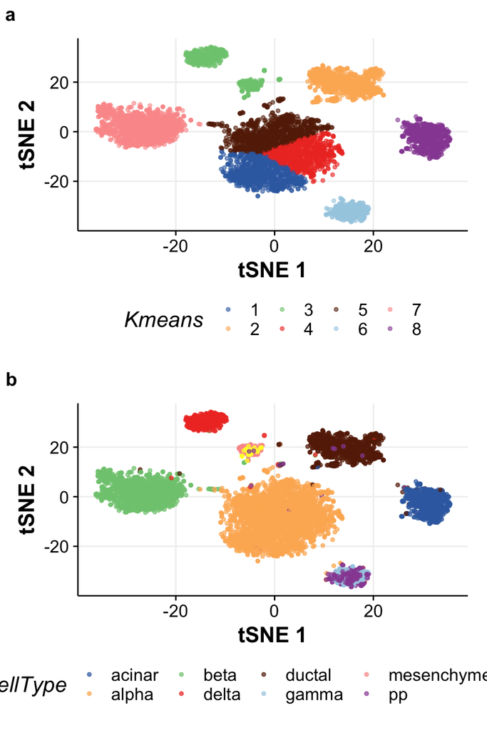

```r
new.tsne <- plot_grid(by.study, by.cell, nrow=2, labels=c("a", "b"))

new.tsne
```

Now that we have re-clustered the batch correct data in a way that is agnostic to the original cell type labels, we can use these to demonstrate the improved power of combining data sets.

## DE analysis of Delta and PP islsets - GSE81076 (CEL-Seq) - raw data

We can see the number of each cell type by each study, noting that some cell types do not appear in all studies.

```r
table(meta.marker$CellType, meta.marker$Study)
```

```
##
##              EMTAB5061 GSE81076 GSE85241 GSE86473
##   acinar           185      238      288        0
##   alpha            874      178      852      944
##   beta             262      160      475      502
##   delta            112       54      198       57
##   ductal           382      332      261        0
##   gamma            194        0        0        0
##   mesenchyme         0       21      138        0
##   pp                 0       24      119       92
##   psc               53        0        0        0
```

```r
table(meta.marker$new.labels, meta.marker$Study)
```

```
##
##              EMTAB5061 GSE81076 GSE85241 GSE86473
##   Acinar           184      249      284        1
##   Alpha            875      190      864      917
##   Beta             264      161      458      477
##   Delta            111       54      216       47
##   Ductal           377      312      252       35
##   Gamma            198       19      125       83
##   Mesenchyme        53       19      101       31
##   Unk                0        3       31        4
```

```r
# select the same raw genes that are in the corrected data
# use the old cell labels from GSE81076
meta.marker$new.labels <- factor(meta.marker$new.labels,
                                labels=c("Unk", "Gamma", "Beta", "Alpha", "Acinar", "Ductal", "Mesenchyme", "Delta"),
                                levels=c("Unk", "Gamma", "Beta", "Alpha", "Acinar", "Ductal", "Mesenchyme", "Delta"))

raw.meta <- meta.marker[meta.marker$Sample %in% gse81076.cells, ]
raw.meta$CellType <- factor(raw.meta$CellType,
                            labels=c("Ductal", "Alpha", "Delta", "Beta", "Acinar", "PP", "Mesenchyme"),
                            levels=c("ductal", "alpha", "delta", "beta", "acinar", "pp", "mesenchyme"))

# set column cell ordering and meta data ordering the same
rownames(raw.meta) <- raw.meta$Sample

raw.design <- model.matrix(~ 0 + CellType, data=raw.meta)
# raw.design <- model.matrix(~ 0 + new.labels, data=raw.meta)

rownames(gse81076.raw) <- gse81076.raw$gene_id
raw.exprs <- gse81076.raw[gse81076.raw$gene_id %in% all.genes, ]
raw.exprs <- raw.exprs[, colnames(gse81076.raw) %in% gse81076.cells]
raw.exprs <- raw.exprs[,colnames(raw.exprs)!="gene_id"]
raw.exprs2 <- raw.exprs[, rownames(raw.meta)]

colnames(raw.design) <- levels(raw.meta$CellType)

# fit a linear model using limma
raw.fit <- limma::lmFit(as.matrix(raw.exprs2),
                        raw.design)

contrast.mat <-  limma::makeContrasts(contrasts="Delta-PP",
                                      levels=raw.design)

raw.fit <- limma::contrasts.fit(raw.fit, contrasts=contrast.mat)

# just select genes with a log Fold change >= 1.0
raw.fit <- limma::treat(raw.fit, lfc=1)
raw.sum.res <- summary(limma::decideTests(raw.fit))

knitr::kable(raw.sum.res)
```

|  | Delta-PP |
| --- | --- |
| -1 | 9 |
| 0 | 568 |
| 1 | 5 |

There are just 14 genes differentially expressed between $\delta$ and PP/$\gamma$ islet cells. Let’s check the identity of these 14 genes; they should at the very least include the two marker genes *SST* and *PPY*.

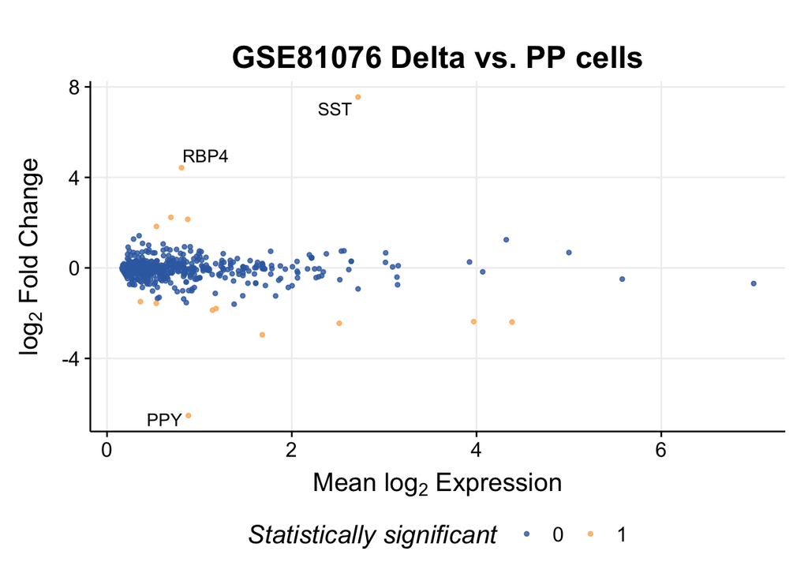

```r
raw.de.res <- limma::topTable(raw.fit, n=Inf, sort="p", p=1.0)
raw.de.res$Sig <- 0
raw.de.res$Sig[raw.de.res$adj.P.Val <= 0.05] <- 1
raw.de.res$Sig <- as.factor(raw.de.res$Sig)

raw.de.res$Diff <- 0
raw.de.res$Diff[raw.de.res$logFC < 0 & raw.de.res$Sig == 1] <- -1
raw.de.res$Diff[raw.de.res$logFC > 0 & raw.de.res$Sig == 1] <- 1

raw.de.res$gene_id <- rownames(raw.de.res)
raw.de.merge <- merge(raw.de.res,  gene_symbol,
                  by.x='gene_id', by.y='external_gene_name', all.x=TRUE)
raw.gene.top <- raw.de.merge$gene_id
raw.gene.top[raw.de.merge$logFC > -3 & raw.de.merge$logFC < 3] <- ""
raw.gene.top[is.na(raw.gene.top)] <- ""

ma <- ggplot(raw.de.merge, aes(x=AveExpr, y=logFC, colour=Sig)) +
  geom_point(size=1, alpha=0.8) + theme_mike() +
  scale_colour_Publication() +
  labs(x=expression(paste("Mean log"[2], " Expression")),
       y=expression(paste("log"[2], " Fold Change")),
       title="GSE81076 Delta vs. PP cells") +
  guides('colour'=guide_legend(title="Statistically significant")) +
  geom_text_repel(aes(label=raw.gene.top),
                  colour='black')

ma
```

```r
unique(raw.de.merge$gene_id[raw.de.merge$Sig == 1])
```

```
##  [1] "ALDH1A1" "ARX"     "CRYBA2"  "GCG"     "HADH"    "PAX6"    "PCP4"
##  [8] "PCSK1"   "PPY"     "RBP4"    "SST"     "STMN2"   "TM4SF4"  "TTR"
```

As expected the two most DE genes are *PPY* (marker gene for PP cells) and *SST* (marker gene for delta cells). There is a TF (*PAX6*) that relevant which is down-regulated in the delta cells relative to the PP cells (it is a master TF for PP cells). Apparently *PAX6* is required for the maintenance of islet cell function [http://journals.plos.org/plosone/article?id=10.1371/journal.pone.0054173], and it is a determinant of islet cell development from their Ngn3+ endocrine progenitor cells.

Now let’s look at what happens when we use the corrected data for all 4 data sets.

### GSE85241 DE analysis

|  | Delta-PP |
| --- | --- |
| -1 | 21 |
| 0 | 540 |
| 1 | 21 |

There are 42 genes DE in the GSE85241 study.

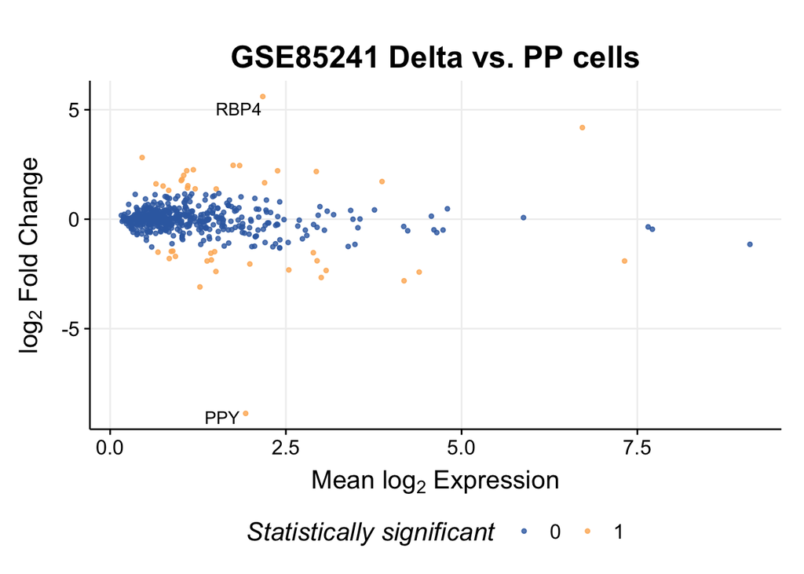

### GSE86473 DE analysis

```
## Coefficients not estimable: Ductal Acinar Mesenchyme
```

|  | Delta-PP |
| --- | --- |
| -1 | 36 |
| 0 | 523 |
| 1 | 23 |

There are 59 DE genes in the GSE86473 study between $\delta$-islets and PP cells.

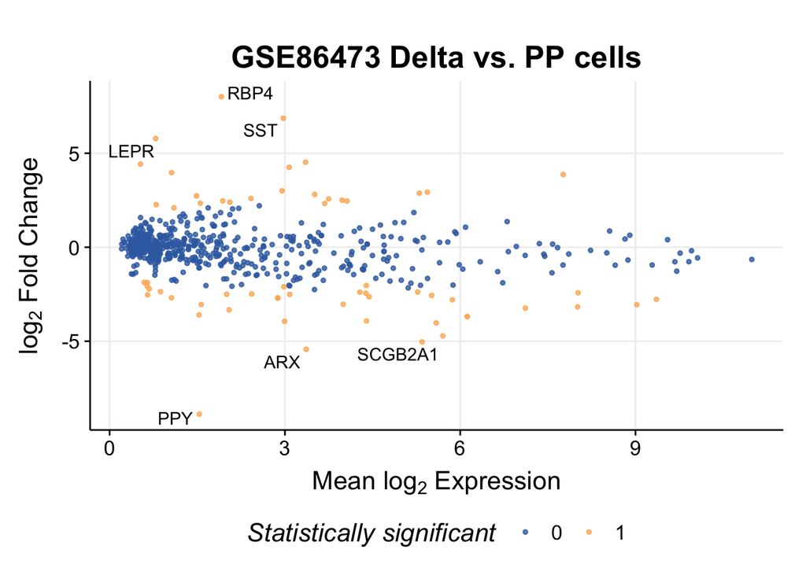

## DE analysis on combined data - Delta vs. PP/Gamma cells

```r
rowSums(table(meta.marker$new.labels, meta.marker$Study))
```

```
##        Unk      Gamma       Beta      Alpha     Acinar     Ductal
##         38        425       1360       2846        718        976
## Mesenchyme      Delta
##        204        428
```

| -1 | 43 |
| --- | --- |
| 0 | 6556 |
| 1 | 31 |

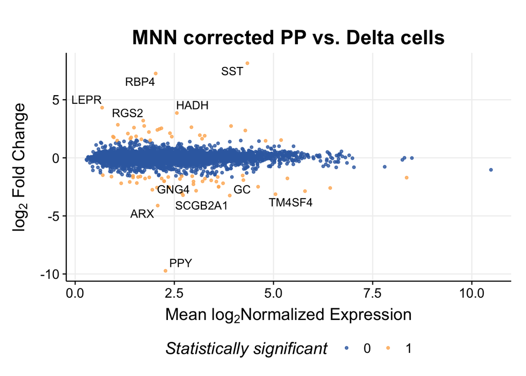

We still see *SST* and *PPY* as the principal differences between delta and PP cells, which indicates nothing stupid is happening. Additionally there are genes such as *GC* (vitamin D binding protein) and *LEPR* leptin receptor that are now DE. In fact, we can look at how the two sets of DE genes intersect; the raw data DE genes should be a subset of the MNN corrected genes.

Let’s also have a volcano plot for both raw and corrected data.

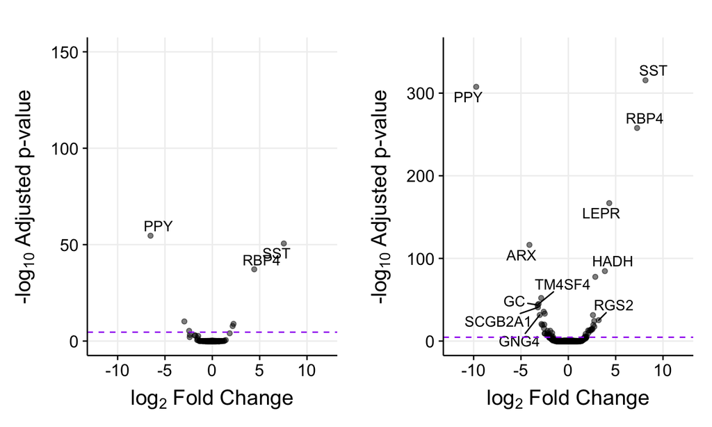

What about genes that are only DE in the total data set, and not in each individual one? The raw DE genes should be a subset of the MNN corrected and combined DE genes.

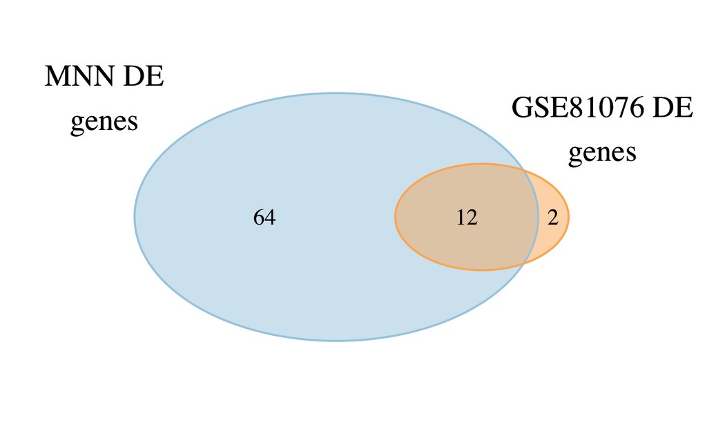

Let’s look at the overlaps for each individual study with the overall combined DE genes.

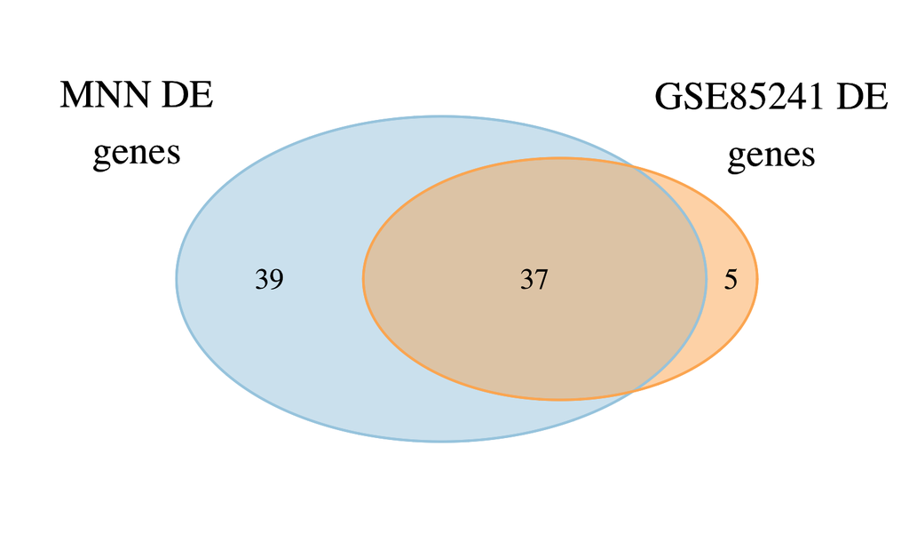

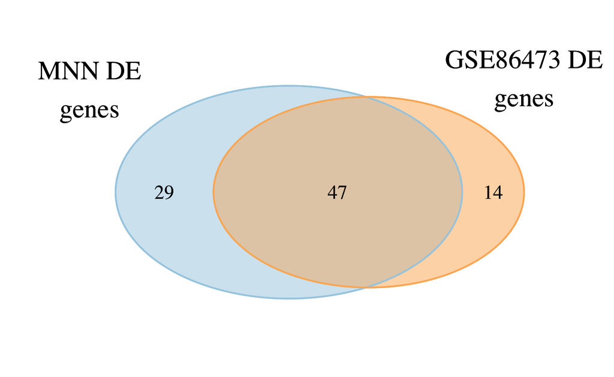

For all 3 studies individually there are 2-14 genes that do not appear in the DE set based on the batch corrected cluster labels. None of these genes overlap with each other, potentially giving a rough idea of the false positive rate within each individual study DE analysis.